# BR PS 1

AP

9/21/2021

## Exercise 1.1

### Part A

Possible prior information could be that brown cows and black-and-white cows exist, and that white milk comes from black-and-white cows. It could also include that the chocolate milk carton has a picture of a brown cow on it.

### Part B

The data that Leslie is weighing against this prior information is the new discovery of chocolate syrup as a thing that exists.

### Part C

The updated conclusion is that chocolate milk is a combination of regular milk and chocolate syrup.

## Exercise 1.2

### Part A

I used to think Ohio was the best state, but then I moved to North Carolina…now I’m even more sure Ohio is the best state #BayesianTweet

### Part B

50% of marriages end in divorce so I’m gonna get married twice so that one of them works out #FrequentistTweet

## Exercise 1.3

The last time I changed my mind was when I tried a great tofu recipe and decided tofu was OK after all.

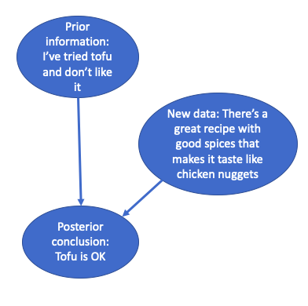

## Exercise 1.4

The last time I changed someone else’s mind was when I convinced my friend that a hot dog is not a sandwich.

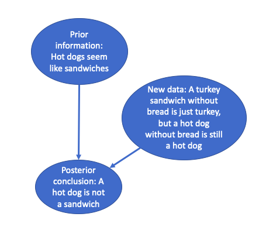

## Exercise 1.5

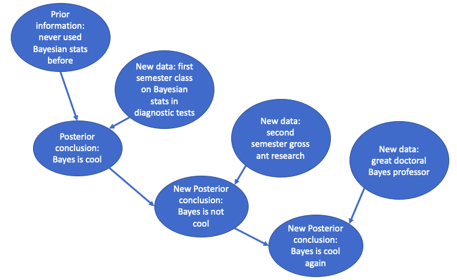

figure 1.5

## Exercise 1.6

### Part A

If I get the job, what’s the probability that I was qualified for the position? If I don’t get the job, what’s the probability that I wasn’t qualified for the position?

### Part B

A Bayesian would say: Given that I’m qualified for the position, what’s the probability of me getting hired?

### Part C

I would rather know the answer to the Bayesian question, because it’s more specific to my situation.

## Exercise 1.7

### Part A

I know about Marvel movies.

### Part B

A possible hypothesis is that Dr. Strange is the most powerful Avenger.

### Part C

Because I’ve seen WandaVision and I know that Wanda created her own pocket reality including her husband and two kids from scratch out of chaos magic, I would be skeptical of this new hypothesis.

### Part D

This is a Bayesian point of view, because my prior knowledge is informing my opinion of the new hypothesis.

## Exercise 1.8

### Part A

Bayesian statistics is useful because it allows us to bring in our prior knowledge about a topic to answer new questions, rather than starting from scratch each time.

### Part B

Bayesian and frequentist statistics use a lot of the same formulas, and they both seek to answer questions about a larger population given a smaller sample. They just go about it differently.